# Hyperspectral Image Processing Demo

## 1. Spatially crop hyperspectral datacube

### First, figure out how to crop the datacube

The Wells study has many plots (usually ~25) in each hyperspectral datacube (captured via drone at 40 m altitude). Therefore, we have to crop each datacube many times to obtain datacubes that only contain pixels representing each individual plot. To do so, we have to first record some information about the datacube and plots within that datacube.

#### Record file location

1. In a spreadsheet, record the **directory** ("directory" column) and **filename** ("fname" column) of the datacube to be processed.
2. Using software that is capable of rendering imagery, open the datacube so you are able to identify the pixel coordinates within an image (i.e., row number and column number of each pixel).
3. Locate the northwest-most plot you'd like to crop from the datacube, and record the **plot ID** ("plot_id" column), the **upper left pixel coordinate in the easting direction** (i.e, column number; "pix_e_ul" column), and the **upper left pixel coordinate in teh northing direction** (i.e, row number; "pix_n_ul" column).
4. This information is the minimum needed (in addition to a file containing the polygon features representing the plots) to be able to crop many individual plots from a full datacube. The following optional parameters may also be recorded in the spreadsheet and will be considered during the batch processing (see hs_process documentation for detailed explanation):
   - Size of the plot as you'd like it cropped in both directions (either pixel units or map units, e.g., meters); "crop_e_pix" and "crop_e_m" refer to the cropped size in the easting direction in pixel units and map units, respectively, and "crop_n_pix" and "crop_n_m" refer to the cropped size in the northing direction in pixel units and map units, respectively.
   - Size of the plot buffer (applied *after* the cropped size); "buf_e_pix" and "buf_e_m" refer to the buffer size in the easting direction in pixel units and map units, respectively, and "buf_n_pix" and "buf_n_m" refer to the cropped size in the northing direction in pixel units and map units, respectively. A positive buffer shrinks the cropped size, and a negative buffer expands the cropped size.
   - Number of plots to crop before terminating the process ("n_plots" column). This parameter can be passed to count the number of plots from the reference plot (i.e., "plot_id" column) from West to East and North to South. When the number of plots is reached, no more plots are cropped even if there are more within the extent of the datacube.

We've recorded this information for a single datacube and saved it to a .csv file:

```python
import pandas as pd

fname_sheet = r'G:\BBE\AGROBOT\Shared Work\Data\PikaImagery4_Reflectance\hs_process_demo\wells_image_cropping.csv'
df_crop = pd.read_csv(fname_sheet)
df_crop
```

|  | date | rep | img_n | directory | fname | plot_id | pix_e_ul | pix_n_ul | crop_e_m | crop_n_m | buf_e_m | buf_n_m | alley_size_n_m | n_plots_x | n_plots_y | n_plots |
| --- | --- | --- | --- | --- | --- | --- | --- | --- | --- | --- | --- | --- | --- | --- | --- | --- |
| 0 | 7/11/2018 | 2 | 7 | G:\BBE\AGROBOT\Shared Work\Data\PikaImagery4_R... | Wells_rep2_20180711_18h19m_pika_gige_7-Radianc... | 1015 | 561 | 237 | 9.17 | 3.049 | 1.5 | 0.6 | 6.132 | 5 | 9 | 15 |

#### Load the geodata

Before actually cropping the datacube, we have to load the file containing the polygon features representing the plots. `Geopandas` will be used to read a .shp file containing the plot ID and polygon geometry (as well as other treatment information) for each plot in the experiment:

```python
import geopandas as gpd

fname_shp = r'G:\BBE\AGROBOT\Shared Work\Data\PikaImagery4_Reflectance\hs_process_demo\plot_bounds\plot_bounds.shp'
gdf = gpd.read_file(fname_shp)
gdf
```

|  | tid | plot | Year | Crop | Drainage | Tillage | Rep | Block | Trt# | Trt_Descri | _count | _sum | _mean | geometry |
| --- | --- | --- | --- | --- | --- | --- | --- | --- | --- | --- | --- | --- | --- | --- |
| 0 | 147 | 724 | 2018 | Corn | U | NT | 2 | 4 | 3 | 80 pre-plant | 17404.0 | 646037.665910 | 37.120068 | POLYGON ((441389.316 4855984.587, 441389.316 4... |
| 1 | 148 | 723 | 2018 | Corn | U | NT | 2 | 4 | 11 | 120 pre-plant | 17404.0 | 688269.788004 | 39.546644 | POLYGON ((441389.316 4855981.539, 441389.316 4... |
| 2 | 149 | 722 | 2018 | Corn | U | NT | 2 | 4 | 12 | 120 pre-plant | 17404.0 | 625298.212945 | 35.928419 | POLYGON ((441389.316 4855978.491, 441389.316 4... |
| 3 | 150 | 721 | 2018 | Corn | U | CT | 2 | 4 | 2 | 40 pre-plant | 17404.0 | 630358.969553 | 36.219201 | POLYGON ((441389.316 4855975.444, 441389.316 4... |
| 4 | 151 | 720 | 2018 | Corn | U | CT | 2 | 4 | 14 | 120 pre-plant | 17633.0 | 577857.182293 | 32.771348 | POLYGON ((441389.316 4855972.396, 441389.316 4... |
| 5 | 152 | 719 | 2018 | Corn | U | CT | 2 | 4 | 10 | 40 pre-plant/160 @ V6 | 17404.0 | 535169.624250 | 30.749806 | POLYGON ((441389.316 4855969.348, 441389.316 4... |
| 6 | 11 | 1515 | 2018 | Corn | U | CT | 3 | 5 | 3 | 80 pre-plant | 17404.0 | 571606.636307 | 32.843406 | POLYGON ((441287.335 4855935.641, 441296.501 4... |
| 7 | 12 | 1516 | 2018 | Corn | U | ST | 3 | 5 | 1 | 0 pre-plant | 17633.0 | 592563.938190 | 33.605395 | POLYGON ((441296.501 4855935.641, 441287.335 4... |
| 8 | 13 | 1415 | 2018 | Corn | U | CT | 3 | 5 | 1 | 0 pre-plant | 17404.0 | 577720.644926 | 33.194705 | POLYGON ((441296.501 4855935.641, 441305.668 4... |
| 9 | 14 | 1416 | 2018 | Corn | U | ST | 3 | 5 | 10 | 40 pre-plant/160 @ V6 | 17633.0 | 562812.369649 | 31.918129 | POLYGON ((441305.668 4855935.641, 441296.501 4... |
| 10 | 15 | 1315 | 2018 | Corn | U | CT | 3 | 5 | 12 | 120 pre-plant | 17404.0 | 619780.706673 | 35.611394 | POLYGON ((441305.668 4855935.641, 441314.834 4... |
| 11 | 16 | 1316 | 2018 | Corn | U | ST | 3 | 5 | 13 | 120 pre-plant | 17633.0 | 641998.194697 | 36.408903 | POLYGON ((441314.834 4855935.641, 441305.668 4... |
| 12 | 17 | 1215 | 2018 | Corn | U | CT | 3 | 5 | 2 | 40 pre-plant | 17480.0 | 543242.937541 | 31.077971 | POLYGON ((441314.834 4855935.641, 441324.001 4... |
| 13 | 18 | 1216 | 2018 | Corn | U | ST | 3 | 5 | 4 | 120 pre-plant | 17710.0 | 621016.372554 | 35.065860 | POLYGON ((441324.001 4855935.641, 441314.834 4... |
| 14 | 19 | 1115 | 2018 | Corn | U | CT | 3 | 5 | 6 | 200 pre-plant | 17404.0 | 587318.929134 | 33.746204 | POLYGON ((441324.001 4855935.641, 441333.167 4... |
| 15 | 20 | 1116 | 2018 | Corn | U | ST | 3 | 5 | 9 | 40 pre-plant/120 @ V6 | 17633.0 | 626792.872915 | 35.546582 | POLYGON ((441333.167 4855935.641, 441324.001 4... |
| 16 | 46 | 1517 | 2018 | Corn | U | ST | 3 | 5 | 2 | 40 pre-plant | 17404.0 | 602697.673690 | 34.629836 | POLYGON ((441296.501 4855938.689, 441287.335 4... |
| 17 | 47 | 1417 | 2018 | Corn | U | ST | 3 | 5 | 3 | 80 pre-plant | 17404.0 | 620709.845284 | 35.664781 | POLYGON ((441305.668 4855938.689, 441296.501 4... |
| 18 | 48 | 1317 | 2018 | Corn | U | ST | 3 | 5 | 5 | 160 pre-plant | 17404.0 | 665183.985880 | 38.220178 | POLYGON ((441314.834 4855938.689, 441305.668 4... |
| 19 | 49 | 1217 | 2018 | Corn | U | ST | 3 | 5 | 15 | 120 pre-plant | 17480.0 | 653334.285198 | 37.376103 | POLYGON ((441324.001 4855938.689, 441314.834 4... |
| 20 | 25 | 815 | 2018 | Corn | D | ST | 2 | 3 | 9 | 40 pre-plant/120 @ V6 | 17480.0 | 588668.613802 | 33.676694 | POLYGON ((441380.150 4855935.641, 441389.316 4... |
| 21 | 26 | 816 | 2018 | Corn | D | NT | 2 | 3 | 12 | 120 pre-plant | 17710.0 | 614135.569985 | 34.677333 | POLYGON ((441389.316 4855935.641, 441380.150 4... |
| 22 | 27 | 715 | 2018 | Corn | D | ST | 2 | 3 | 6 | 200 pre-plant | 17404.0 | 597447.447098 | 34.328169 | POLYGON ((441389.316 4855935.641, 441398.483 4... |
| 23 | 28 | 716 | 2018 | Corn | D | NT | 2 | 3 | 2 | 40 pre-plant | 17633.0 | 612118.152826 | 34.714351 | POLYGON ((441398.483 4855935.641, 441389.316 4... |
| 24 | 29 | 615 | 2018 | Corn | D | ST | 2 | 3 | 3 | 80 pre-plant | 17404.0 | 597014.002273 | 34.303264 | POLYGON ((441398.483 4855935.641, 441407.649 4... |
| 25 | 30 | 616 | 2018 | Corn | D | NT | 2 | 3 | 4 | 120 pre-plant | 17633.0 | 613125.592092 | 34.771485 | POLYGON ((441407.649 4855935.641, 441398.483 4... |
| 26 | 21 | 1015 | 2018 | Corn | D | ST | 2 | 3 | 12 | 120 pre-plant | 17404.0 | 613724.547337 | 35.263419 | POLYGON ((441361.817 4855935.641, 441370.983 4... |
| 27 | 22 | 1016 | 2018 | Corn | D | NT | 2 | 3 | 9 | 40 pre-plant/120 @ V6 | 17633.0 | 621497.541960 | 35.246274 | POLYGON ((441370.983 4855935.641, 441361.817 4... |
| 28 | 23 | 915 | 2018 | Corn | D | ST | 2 | 3 | 15 | 120 pre-plant | 17404.0 | 597690.791238 | 34.342151 | POLYGON ((441370.983 4855935.641, 441380.150 4... |
| 29 | 24 | 916 | 2018 | Corn | D | NT | 2 | 3 | 11 | 120 pre-plant | 17633.0 | 626566.637644 | 35.533751 | POLYGON ((441380.150 4855935.641, 441370.983 4... |
| ... | ... | ... | ... | ... | ... | ... | ... | ... | ... | ... | ... | ... | ... | ... |
| 690 | 154 | 135 | 2018 | Sb | U | ST | 1 | 2 | 1 | Untreated | 17633.0 | 610024.262288 | 34.595603 | POLYGON ((441481.352 4856027.290, 441481.352 4... |
| 691 | 155 | 134 | 2018 | Sb | U | ST | 1 | 2 | 9 | Untreated | 17404.0 | 654880.534878 | 37.628162 | POLYGON ((441481.352 4856024.242, 441481.352 4... |
| 692 | 100 | 935 | 2018 | Sb | U | ST | 2 | 4 | 9 | Untreated | 17633.0 | 556793.942211 | 31.576813 | POLYGON ((441370.983 4856024.242, 441370.983 4... |
| 693 | 101 | 934 | 2018 | Sb | U | ST | 2 | 4 | 12 | Cruiser 5RS | 17404.0 | 646973.580000 | 37.173844 | POLYGON ((441370.983 4856021.194, 441370.983 4... |
| 694 | 102 | 933 | 2018 | Sb | U | NT | 2 | 4 | 6 | Untreated | 17404.0 | 624071.874533 | 35.857956 | POLYGON ((441370.983 4856018.146, 441370.983 4... |
| 695 | 103 | 932 | 2018 | Sb | U | NT | 2 | 4 | 10 | Untreated | 17404.0 | 602394.086184 | 34.612393 | POLYGON ((441370.983 4856015.099, 441370.983 4... |
| 696 | 104 | 931 | 2018 | Sb | U | NT | 2 | 4 | 13 | CruiserMaxx Vibrance + 7.5G ApronXL | 17404.0 | 543417.057322 | 31.223688 | POLYGON ((441370.983 4856012.051, 441370.983 4... |
| 697 | 118 | 835 | 2018 | Sb | U | ST | 2 | 4 | 11 | Vibrance TRIO | 17710.0 | 573532.005649 | 32.384642 | POLYGON ((441380.150 4856024.242, 441380.150 4... |
| 698 | 119 | 834 | 2018 | Sb | U | ST | 2 | 4 | 13 | CruiserMaxx Vibrance + 7.5G ApronXL | 17480.0 | 659279.710413 | 37.716231 | POLYGON ((441380.150 4856021.194, 441380.150 4... |
| 699 | 120 | 833 | 2018 | Sb | U | NT | 2 | 4 | 5 | Untreated | 17480.0 | 632878.660751 | 36.205873 | POLYGON ((441380.150 4856018.146, 441380.150 4... |
| 700 | 121 | 832 | 2018 | Sb | U | NT | 2 | 4 | 12 | Cruiser 5RS | 17480.0 | 595466.316941 | 34.065579 | POLYGON ((441380.150 4856015.099, 441380.150 4... |
| 701 | 122 | 831 | 2018 | Sb | U | NT | 2 | 4 | 9 | Untreated | 17480.0 | 574879.093907 | 32.887820 | POLYGON ((441380.150 4856012.051, 441380.150 4... |
| 702 | 123 | 830 | 2018 | Sb | U | CT | 2 | 4 | 9 | Untreated | 17710.0 | 629544.769882 | 35.547418 | POLYGON ((441380.150 4856009.003, 441380.150 4... |
| 703 | 124 | 829 | 2018 | Sb | U | CT | 2 | 4 | 12 | Cruiser 5RS | 17480.0 | 591501.478777 | 33.838757 | POLYGON ((441380.150 4856005.955, 441380.150 4... |
| 704 | 125 | 828 | 2018 | Sb | U | CT | 2 | 4 | 3 | Untreated | 17480.0 | 639856.188300 | 36.605045 | POLYGON ((441380.150 4856002.908, 441380.150 4... |
| 705 | 135 | 736 | 2018 | Sb | U | ST | 2 | 4 | 8 | Untreated | 17404.0 | 609805.407490 | 35.038233 | POLYGON ((441389.316 4856027.290, 441389.316 4... |
| 706 | 136 | 735 | 2018 | Sb | U | ST | 2 | 4 | 6 | Untreated | 17633.0 | 610876.656585 | 34.643944 | POLYGON ((441389.316 4856024.242, 441389.316 4... |
| 707 | 137 | 734 | 2018 | Sb | U | ST | 2 | 4 | 4 | Untreated (UTC) | 17404.0 | 683560.563736 | 39.276061 | POLYGON ((441389.316 4856021.194, 441389.316 4... |
| 708 | 138 | 733 | 2018 | Sb | U | NT | 2 | 4 | 4 | Untreated (UTC) | 17404.0 | 652145.403042 | 37.471007 | POLYGON ((441389.316 4856018.146, 441389.316 4... |
| 709 | 139 | 732 | 2018 | Sb | U | NT | 2 | 4 | 8 | Untreated | 17404.0 | 624390.482314 | 35.876263 | POLYGON ((441389.316 4856015.099, 441389.316 4... |
| 710 | 140 | 731 | 2018 | Sb | U | NT | 2 | 4 | 2 | Untreated | 17404.0 | 637860.417404 | 36.650219 | POLYGON ((441389.316 4856012.051, 441389.316 4... |
| 711 | 141 | 730 | 2018 | Sb | U | CT | 2 | 4 | 1 | Untreated | 17633.0 | 659343.052938 | 37.392562 | POLYGON ((441389.316 4856009.003, 441389.316 4... |
| 712 | 142 | 729 | 2018 | Sb | U | CT | 2 | 4 | 11 | Vibrance TRIO | 17404.0 | 656068.055262 | 37.696395 | POLYGON ((441389.316 4856005.955, 441389.316 4... |
| 713 | 143 | 728 | 2018 | Sb | U | CT | 2 | 4 | 4 | Untreated (UTC) | 17404.0 | 660730.011557 | 37.964262 | POLYGON ((441389.316 4856002.908, 441389.316 4... |
| 714 | 156 | 133 | 2018 | Sb | U | NT | 1 | 2 | 5 | Untreated | 17404.0 | 654881.130182 | 37.628196 | POLYGON ((441481.352 4856021.194, 441481.352 4... |
| 715 | 157 | 132 | 2018 | Sb | U | NT | 1 | 2 | 9 | Untreated | 17404.0 | 577383.413528 | 33.175328 | POLYGON ((441481.352 4856018.146, 441481.352 4... |
| 716 | 158 | 131 | 2018 | Sb | U | NT | 1 | 2 | 4 | Untreated (UTC) | 17404.0 | 653578.367925 | 37.553342 | POLYGON ((441481.352 4856015.099, 441481.352 4... |
| 717 | 159 | 130 | 2018 | Sb | U | CT | 1 | 2 | 1 | Untreated | 17633.0 | 689269.898966 | 39.089769 | POLYGON ((441481.352 4856012.051, 441481.352 4... |
| 718 | 160 | 129 | 2018 | Sb | U | CT | 1 | 2 | 6 | Untreated | 17404.0 | 647321.973672 | 37.193862 | POLYGON ((441481.352 4856009.003, 441481.352 4... |
| 719 | 161 | 128 | 2018 | Sb | U | CT | 1 | 2 | 2 | Untreated | 17404.0 | 660085.658641 | 37.927238 | POLYGON ((441481.352 4856005.955, 441481.352 4... |

720 rows × 14 columns

#### Use hs_process to batch crop the datacube

There are three methods for spatially cropping a datacube, and we will use `method = many_gdf` (see the documentation for a complete description of each method). `method = many_gdf` basically overlays the datacube over the geodata to determine which plots are present in the datacube, then individually crops each plot from West to East and North to South starting with the reference plot "plot_id" column above. There are also options for modifying the output foler name, a name to append to the filename of the cropped datacube, and whether to output a geotiff of the cropped image (see the documentation for a complete list of optional parameters). The `batch.spatial_crop()` function reads the spreadsheet and conducts the cropping based on the passed parameters:

```
Spatially cropping: G:\BBE\AGROBOT\Shared Work\Data\PikaImagery4_Reflectance\hs_process_demo\Wells_rep2_20180711_18h19m_pika_gige_7-Radiance Conversion-Georectify Airborne Datacube-Reflectance from Radiance Data and Measured Reference Spectrum.bip

Saving G:\BBE\AGROBOT\Shared Work\Data\PikaImagery4_Reflectance\hs_process_demo\spatial_crop_many_gdf\Wells_rep2_20180711_18h19m_pika_gige_7-spatial-crop-1015.bip
```

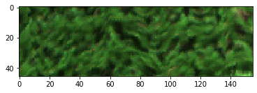

```
Saving G:\BBE\AGROBOT\Shared Work\Data\PikaImagery4_Reflectance\hs_process_demo\spatial_crop_many_gdf\Wells_rep2_20180711_18h19m_pika_gige_7-spatial-crop-915.bip
```

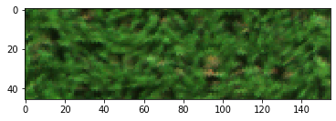

```
Saving G:\BBE\AGROBOT\Shared Work\Data\PikaImagery4_Reflectance\hs_process_demo\spatial_crop_many_gdf\Wells_rep2_20180711_18h19m_pika_gige_7-spatial-crop-815.bip
```

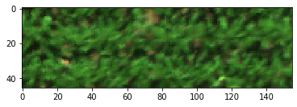

```
Saving G:\BBE\AGROBOT\Shared Work\Data\PikaImagery4_Reflectance\hs_process_demo\spatial_crop_many_gdf\Wells_rep2_20180711_18h19m_pika_gige_7-spatial-crop-715.bip
```

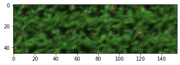

```
Saving G:\BBE\AGROBOT\Shared Work\Data\PikaImagery4_Reflectance\hs_process_demo\spatial_crop_many_gdf\Wells_rep2_20180711_18h19m_pika_gige_7-spatial-crop-615.bip
```

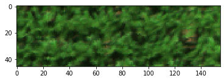

```
Saving G:\BBE\AGROBOT\Shared Work\Data\PikaImagery4_Reflectance\hs_process_demo\spatial_crop_many_gdf\Wells_rep2_20180711_18h19m_pika_gige_7-spatial-crop-1014.bip
```

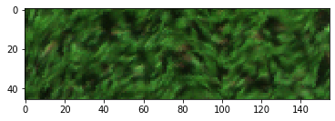

```
Saving G:\BBE\AGROBOT\Shared Work\Data\PikaImagery4_Reflectance\hs_process_demo\spatial_crop_many_gdf\Wells_rep2_20180711_18h19m_pika_gige_7-spatial-crop-914.bip
```

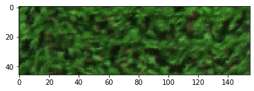

```
Saving G:\BBE\AGROBOT\Shared Work\Data\PikaImagery4_Reflectance\hs_process_demo\spatial_crop_many_gdf\Wells_rep2_20180711_18h19m_pika_gige_7-spatial-crop-814.bip
```

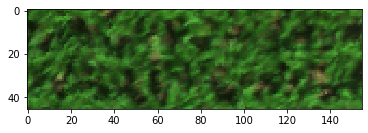

```
Saving G:\BBE\AGROBOT\Shared Work\Data\PikaImagery4_Reflectance\hs_process_demo\spatial_crop_many_gdf\Wells_rep2_20180711_18h19m_pika_gige_7-spatial-crop-714.bip
```

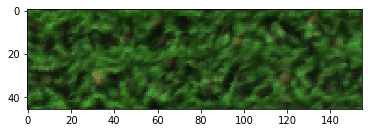

```
Saving G:\BBE\AGROBOT\Shared Work\Data\PikaImagery4_Reflectance\hs_process_demo\spatial_crop_many_gdf\Wells_rep2_20180711_18h19m_pika_gige_7-spatial-crop-614.bip
```

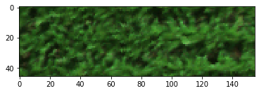

```
Saving G:\BBE\AGROBOT\Shared Work\Data\PikaImagery4_Reflectance\hs_process_demo\spatial_crop_many_gdf\Wells_rep2_20180711_18h19m_pika_gige_7-spatial-crop-1013.bip
```

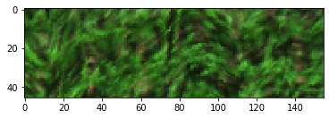

```
Saving G:\BBE\AGROBOT\Shared Work\Data\PikaImagery4_Reflectance\hs_process_demo\spatial_crop_many_gdf\Wells_rep2_20180711_18h19m_pika_gige_7-spatial-crop-913.bip
```

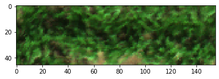

```
Saving G:\BBE\AGROBOT\Shared Work\Data\PikaImagery4_Reflectance\hs_process_demo\spatial_crop_many_gdf\Wells_rep2_20180711_18h19m_pika_gige_7-spatial-crop-813.bip
```

```
Clipping input data to the valid range for imshow with RGB data ([0..1] for floats or [0..255] for integers).
```

[3 more figures not shown]

```python
from hs_process import batch

hsbatch = batch()
method = 'many_gdf'  # options: 'single', 'many_grid', or 'many_gdf'
hsbatch.spatial_crop(fname_sheet,
                     folder_name='spatial_crop_{0}'.format(method),
                     name_append='spatial-crop', geotiff=True, method=method,
                     gdf=gdf, out_force=True)
```

#### Display the cropped geotiffs

Note that the loaded geotiffs appear pretty dark. This is because of the limited rendering functionality of `rasterio`. The pixel values of the both the datacubes and the geotiffs are in units of reflectance (range from 0.0 to 1.0).

```
(4855917.106000001, 4855945.041)
```

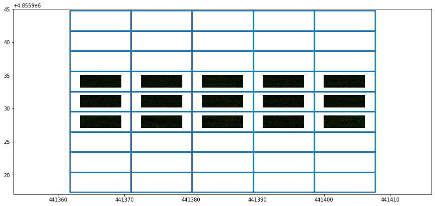

```python
import matplotlib.pyplot as plt
import rasterio as rast
from rasterio.plot import show

base_dir = r'G:\BBE\AGROBOT\Shared Work\Data\PikaImagery4_Reflectance\hs_process_demo\spatial_crop_many_gdf'
tif_list = hsbatch._recurs_dir(base_dir, search_ext='.tif', level=0)

gdf_filter = gdf.copy()
# gdf_filter = hsbatch.my_spatial_mod._overlay_gdf(hsbatch.io.spyfile, gdf)

fig, ax = plt.subplots(figsize=(15, 15))
gdf_filter.plot(ax=ax, alpha=0.9, column='Crop', facecolor='none', edgecolor='blue', linewidth=3)

left = 1e9
bottom = 1e9
right = -1e9
top = -1e9
for fname_tif in tif_list:
    tif = rast.open(fname_tif)
    show(tif.read(), ax=ax, transform=tif.transform, adjust='linear')
    if tif.bounds[0] < left:
        left = tif.bounds[0]
    if tif.bounds[1] < bottom:
        bottom = tif.bounds[1]
    if tif.bounds[2] > right:
        right = tif.bounds[2]
    if tif.bounds[3] > top:
        top = tif.bounds[3]

# bbox = gdf_filter.total_bounds
plt.xlim((left-10, right+10))
plt.ylim((bottom-10, top+10))
```